# 4. Using map projections

Dan Kelley (https://orcid.org/0000-0001-7808-5911)

2020-02-21

**Abstract.** An overview of the handling of map projections in oce is presented, along with a few examples of common projections.

# 1 Introduction

Map projections provide methods for representing the three-dimensional surface of the earth as two-dimensional plots. Although most oceanographers are likely to be familiar with the basic ideas of map projection, they may find it helpful to consult the wide literature on this topic, whether to learn about the details of individual projections and to get advice on the best choice of projection for a particular task. Snyder (1987), Snyder (1993) and Snyder and Voxland (1994) are all excellent sources on these topics, and the first and last of these are available for free online.

There are far too many projections to illustrate here. See http://dankelley.github.io/r/2015/04/03/oce-proj.html for a blog item that provides examples of the available projections. Note that some have a problem with spurious horizontal lines. This can result from coastline segments that cross the edge of the plotting area, and getting rid of this is tricky enough to be the heart of the longest-lived bug in the `oce` issue list, i.e. https://github.com/dankelley/oce/issues/388. In some instances the function `coastlineCut()` can help, but it is provisional and subject to change.

# 2 Avoiding projections for limited-area plots

For map views that span only a few tens or hundreds of kilometers, it may be sufficient to plot directly, in rectilinear longitude-latitude space, but with an appropriate aspect ratio so that circular islands will appear circular in the plot.

To see the need for setting the aspect ratio, consider the following view of eastern North America.

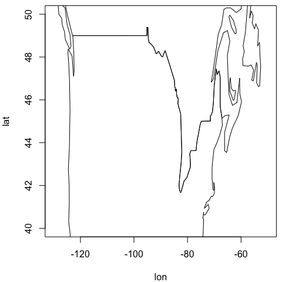

```r
library(oce)
data(coastlineWorld)
lon <- coastlineWorld[["longitude"]]
lat <- coastlineWorld[["latitude"]]
par(mar=c(4, 4, 0.5, 0.5))
plot(lon, lat, type="l",
     xlim=c(-130, -50), ylim=c(40, 50))
```

Readers familiar with this region will notice that the coastline shapes are distorted. The solution to this problem is to set the `asp` argument of `plot()` to a value that will compensate for meridional convergence at the poles, as below.

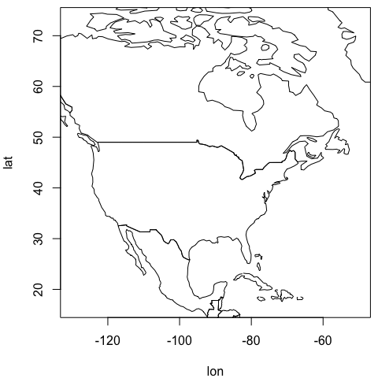

```r
par(mar=c(4, 4, 0.5, 0.5))
plot(lon, lat, type="l",
     xlim=c(-130, -50), ylim=c(40, 50), asp=1/cos(45*pi/180))
```

Although the above approach is not exactly taxing, the effort of setting the aspect ratio and setting line-type plots can be spared by using the generic `plot()` function for `coastline` objects, as follows.

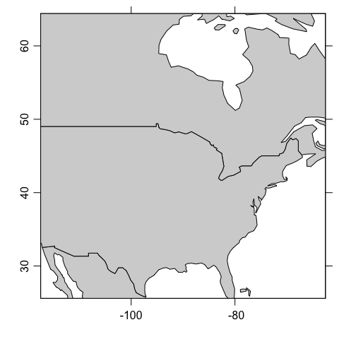

```r
plot(coastlineWorld,
     longitudelim=c(-130, -50), latitudelim=c(40, 50))
```

The graphs shown above share a common stength: the axes for longitude and latitude are orthogonal, and the scale along each axis is linear. This makes it easy for readers to identify the location of features of the diagrams. However, using linear axes on large-scale views leads to distortions of coastline shapes and relative feature sizes, and motivates the use of map projections. (Readers who question the previous sentence are again encouraged to consult some of the references in the bibliography.)

# 3 Choosing a map projection

## 3.1 World views

```r
data(coastlineWorld)
```

The function used to produce maps with projections is `mapPlot`, and with default arguments it produces

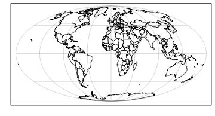

World coastline with default (Mollweide) projection.

```r
par(mar=c(1.5, 1.5, 0.5, 0.5))
mapPlot(coastlineWorld)
```

This default plot uses the Mollweide projection (see any of the Snyder references in the bibliography), which is set by the default value `"+proj=moll"` for `mapPlot`. Another popular world view is the Robinson projection, which has been used by Rand McNally, the National Geographic Society, and other groups.

**Exercise 1.** Plot the world with a Robinson projection, using gray shading for land.

**Exercise 2.** Plot an image of world topography with the Mollweide projection.

## 3.2 Polar views

In both these views (and in most world-spanning projections) there is substantial distortion at high latitudes. The Stereographic projection offers a solution to this problem, e.g. in the following (which employs a trick on the latitude limit, specifying an image point on the other side of the planet, with the pole in between).

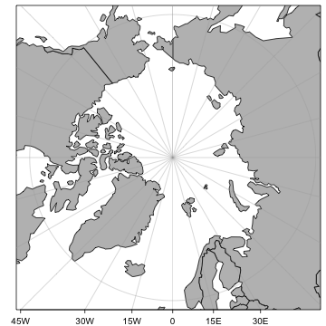

Polar view with stereographic projection.

```r
par(mar=c(1.5, 1.5, 0.5, 0.5))
mapPlot(coastlineWorld, longitudelim=c(-130, 50), latitudelim=c(60, 120),
       projection="+proj=stere +lat_0=90", col='gray')
```

This Arctic example also illustrates the specification of extra arguments in the `projection` value, in this case the base latitude being set to the north pole. See the table in the documentation for `mapPlot` for a listing of arguments, and for citations to external resources that explain what they mean.

**Exercise 3.** Draw a view of Antarctica and the Southern Ocean.

## 3.3 Mid-latitude views

The Lambert Conformal view is often used in maps that span wide longitudal ranges, e.g. a map of Canada may be produced as follows.

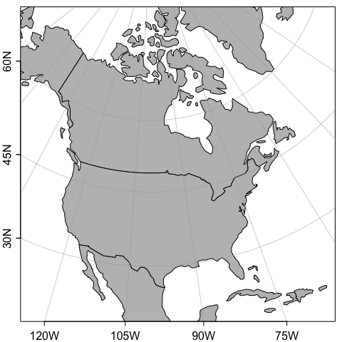

```r
par(mar=c(1.5, 1.5, 0.5, 0.5))
mapPlot(coastlineWorld,
         longitudelim=c(-130,-55), latitudelim=c(35, 60),
         projection="+proj=lcc +lat_0=30 +lat_1=60 +lon_0=-100", col='gray')
```

# 4 Adding to map plots

Several functions are provided by oce to draw additional features on maps. These include `mapText` for adding text, `mapPoints` for adding points, `mapLines` for adding lines, `mapContour` for adding contours, and `mapImage` for adding images. Each of these requires a map to have been drawn first with `mapPlot`. The interfaces ought to be similar enough to base-R functions that readers can decide how to accomplish common tasks.

**Exercise 6.** Plot the world with the Goode projection, superimposing sea surface temperature as contours.

# 5 Solutions to exercises

**Exercise 1.** Plot the world with a Robinson projection, using gray shading for land.

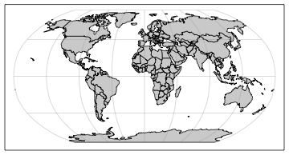

World coastline with Robinson projection.

```r
par(mar=rep(0.5, 4))
mapPlot(coastlineWorld, col="lightgray", projection="+proj=robin")
```

**Exercise 2.** Plot an image of world topography with the Mollweide projection.

Note that some adjustment of the margins is required to fit the colorbar.

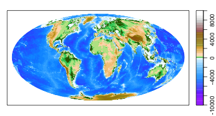

World topography with Mollweide projection.

```r
par(mar=c(1.5, 1, 1.5, 1))
data(topoWorld)
topo <- decimate(topoWorld, 2) # coarsen grid: 4X faster plot
lon <- topo[["longitude"]]
lat <- topo[["latitude"]]
z <- topo[["z"]]
cm <- colormap(name="gmt_globe")
drawPalette(colormap=cm)
mapPlot(coastlineWorld, projection="+proj=moll", grid=FALSE, col="lightgray")
mapImage(lon, lat, z, colormap=cm)
```

**Exercise 3.** Draw a view of Antarctica and the Southern Ocean.

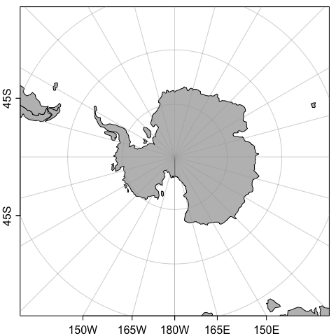

```r
par(mar=c(1.5, 1.5, 0.5, 0.5))
mapPlot(coastlineWorld, longitudelim=c(-180, 180), latitudelim=c(-130, -50),
       projection="+proj=stere +lat_0=-90", col='gray', grid=15)
```

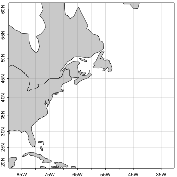

```r
par(mar=c(1.5, 1.5, 0.5, 0.5))
mapPlot(coastlineWorld, col="lightgray",
        projection="+proj=merc",
        longitudelim=c(-80, -40), latitudelim=c(20, 60))
```

In the solution given below, note how the `lon_0` argument is set to be at the central value of `longitudelim`. This makes the $60^\circ$W line be vertical on the plot. The settings for `lat_1` and `lat_2` are the locations at which the cone intersects the earth, so distortion is minimized at those latitudes. Note how the lines of constant longitude are changed, compared with those in the Mercator view. It may be informative to compare the relative ratio of the area of Nova Scotia (at $45^\circ$N) and Ungava Bay (at $60^\circ$N) in this Albers Equal-Area projection, and the Mercator projection shown in the previous diagram.

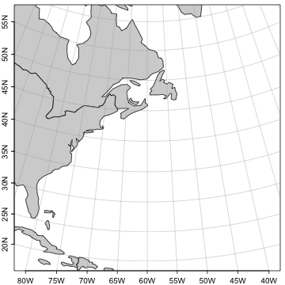

```r
par(mar=c(1.5, 1.5, 0.5, 0.5))
mapPlot(coastlineWorld, col="lightgray",
        projection="+proj=aea +lat_1=30 +lat_2=50 +lon_0=-60",
        longitudelim=c(-80, -40), latitudelim=c(20, 60))
```

**Exercise 6.** Plot the world with the Goode projection, superimposing sea surface temperature as contours.

Note that the temperature is provided by the `ocedata` package.

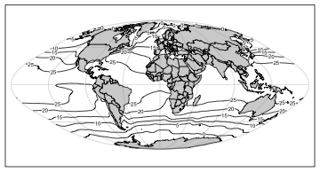

SST contours with the Goode projection

```r
par(mar=rep(0.5, 4))
mapPlot(coastlineWorld, projection="+proj=goode", col="lightgray")
if (requireNamespace("ocedata", quietly=TRUE)) {
    data(levitus, package="ocedata")
    mapContour(levitus[['longitude']], levitus[['latitude']], levitus[['SST']])
}
```

# 6 References

PROJ. PROJ.4 6.0.0 Documentation.” Accessed March 7, 2019. https://proj4.org/.

Snyder, John P. Map Projections—a Working Manual. Washington: U.S. Geological survey professional paper 1395, 1987. https://pubs.usgs.gov/pp/1395/report.pdf.

Snyder, John Parr. Flattening the Earth: Two Thousand Years of Map Projections. Chicago, IL: University of Chicago Press, 1993. https://www.press.uchicago.edu/ucp/books/book/chicago/F/bo3632853.html.

Snyder, John P., and Philip M. Voxland. U. S. Geological Survey Professional Paper. Washington, DC, USA: U. S. Department of the Interior: U. S. Geological Survey, 1994. https://pubs.er.usgs.gov/publication/pp1453.